# Modeling | Swire Coca-Cola Capstone Project

IS 6813-001, Spring 2025 | Group 3

Authors

Adam Bushman

Georgia Christodoulou

Tyler Swanson

Zac Mendenhall

Published

March 18, 2025

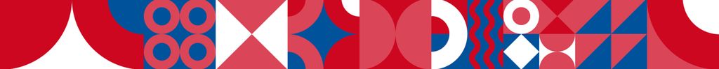

# Business Problem Statement

Regional beverage bottler Swire Coca-Cola (SCCU) relies on two business models: 1) “Red Truck”, which features high-volume customers serviced personally by Swire, and 2) “White Truck” or “Alternate Route to Market”, which entails smaller customers serviced by a third-party distributor.

Swire’s current segmenting strategy has led to misallocation of resources, inflated expenses, and missed opportunities from clients with high-growth potential. Swire aims to better algin their customers with the business proposition of these models by identifying customer characteristics and rdering behavior that better determines the right business model for the long-term relationship.

# Modeling Introduction

Our approach enhances Swire Coca-Cola’s customer segmentation by analyzing transactional and profile data to identify key patterns. We apply clustering techniques to group similar customers and predictive modeling to forecast ordering behavior. These insights help optimize resource allocation, reduce costs, and identify high-growth opportunities.

In **Approach #1**, Tyler applies PAM clustering with Gower’s Distance to segment customers based on purchasing behavior, handling mixed data types and assigning missing clusters using KNN, Centroid Matching, and Random Assignment. A Random Forest model is then trained to predict high-value orders, leveraging customer attributes, clustering results, and neighbor-based features, with SMOTE balancing and hyperparameter tuning optimizing performance.

In **Approach #2**, Adam will explore an different approach to clustering, one that leverages Principal Component Analysis and two different algorithms: kmeans and hierarchical. The goal is to identify unique customer groupings that could identify those that are 1) definitely red truck, 2) definitely white truck, and 3) it depends.

In **Approach #3**, Zac applied a clustering approach to transactional data, focusing on the relationship between gallons and cases ordered versus what was actually delivered. He created a new column that captures fulfillment and returns, providing a clearer view of how orders are being met.

In **Approach #4**, Georgia chose a forecasting approach to predict customer-level future orders with the goal of identifying trends in customer behavior and potential growth patterns. Due to the limited data and time constraints, I developed a base-level forecast model that incorporates features like lag values, rolling averages, and growth rates to capture recent order patterns and momentum. While this model offers some insights, there’s opportunity for further improvement by adding advanced features, improving segmentation, and exploring additional data sources.

# Data Preparation

## Approach to Wrangling

The dataset undergoes aggregation, merging, and transformation to optimize it for PAM clustering with Gower’s Distance and Random Forest classification.

First, key numerical and categorical features are selected, with categorical variables encoded and missing values imputed (“999” for categorical, median values for numerical). Data is aggregated at the customer-year level, calculating total and average order values, and deriving customer tenure from the difference between the latest transaction date and first recorded delivery. To maintain consistency, a mode function (get_mode) is applied to categorical variables such as trade channel, sub-trade channel, order type, and local market partner status, ensuring representative values for each customer. The resulting dataset, customer_full_summary, merges customer transaction summaries with these aggregated categorical features.

To incorporate local market dynamics, customer_full_summary is merged with customer_neighbor_fields, adding neighbor-based attributes such as average order transactions, return frequency, primary group distribution, and geospatial attributes (latitude, longitude, zip code). These additional features enhance segmentation and predictive modeling by capturing regional purchasing patterns.

Additionally, a Local Market Partner (LMP) subset is created by filtering customers who purchase only fountain drinks while excluding CO2, cans, and bottles (local_market_partner = 1 and co2_customer = 0). This segmentation allows for a more targeted analysis of smaller, high-frequency purchasers.

## Libraries & Data

We begin by setting up our session with the necessary libraries and data provided by Swire. These will be referenced often throughout this document.

```r
setwd("/home/adam-bushman/All Projects/delivery-standardization-group")

# Read files into session
transactions <- as.data.frame(data.table::fread("data/original/transactional_data.csv"))
customer_address <- read.csv("data/original/customer_address_and_zip_mapping.csv")
customer_profile <- read.csv("data/original/customer_profile.csv")
delivery_cost <- readxl::read_xlsx('data/original/delivery_cost_data.xlsx')

customer_neighbor_fields <- as.data.table(data.table::fread("data/derived/customer_neighbor_fields.csv"))
customer_neighbor_fields[, customer_number := as.character(customer_number)]
```

## Wrangling steps

### Prepping the Cost Data

```r
delivery_cost_expanded <-
    delivery_cost |>
    # Split the volume range into an object
    mutate(
        range_obj = purrr::map(`Vol Range`, str_split, " - ")
    ) |>
    # Unnest the object for individual reference
    unnest(range_obj) |>
    unnest_wider(range_obj, names_sep = "_") |>
    # Handle the "1350+" scenario
    mutate(
        min_vol = purrr::map_chr(range_obj_1, str_replace, "\\+", ""),
        max_vol  = ifelse(is.na(range_obj_2), (2^31) - 1, range_obj_2)
    ) |>
    # Turn volumes from charaters to integers
    mutate(
        across(min_vol:max_vol, as.integer)
    ) |>
    # Drop irrelevant columns
    select(-c(range_obj_1, range_obj_2, `Vol Range`))
```

```r
annual_cust_volume <-
    # Take transaction level data
    transactions |>
    # Bring in the customer profile for the `Cold Drink Channel`
    inner_join(
        customer_profile,
        join_by(CUSTOMER_NUMBER)
    ) |>
    # Get annual cases/gallons by customer
    group_by(YEAR, CUSTOMER_NUMBER, COLD_DRINK_CHANNEL) |>
    summarise(
        annual_cases = sum(DELIVERED_CASES),
        annual_gallons = sum(DELIVERED_GALLONS),
        .groups = "drop"
    )
```

```r
# Join delivery cost estimates to each customer's annual volume to assign appropriate tiered rates
delivery_cost_tiers <-
    annual_cust_volume |>

    # Join delivery costs for *case-based* products (excluding Fountain)
    left_join(
        delivery_cost_expanded |>
            filter(`Applicable To` != 'Fountain'),  # Filter to non-fountain products
        join_by(
            COLD_DRINK_CHANNEL == `Cold Drink Channel`,  # Match by drink channel
            annual_cases >= min_vol,  # Ensure volume falls within the defined min
            annual_cases <= max_vol   # Ensure volume falls within the defined max
        )
    ) |>

    # Join delivery costs for *gallon-based* products (only Fountain)
    left_join(
        delivery_cost_expanded |>
            filter(`Applicable To` == 'Fountain'),  # Filter only fountain records
        join_by(
            COLD_DRINK_CHANNEL == `Cold Drink Channel`,  # Match by drink channel
            annual_gallons >= min_vol,  # Match gallon volume to range
            annual_gallons <= max_vol
        ),
        suffix = c(".c", ".g")  # Add suffixes to distinguish overlapping column names
    ) |>

    # Select only the relevant fields for output
    select(
        YEAR, CUSTOMER_NUMBER,
        case_delivery_cost = `Median Delivery Cost.c`,  # Cost per case delivery
        gallon_delivery_cost = `Median Delivery Cost.g`  # Cost per gallon delivery
    )

# Take a peek
head(delivery_cost_tiers)
```

[output not shown]

### Prep the Customer Address Object

```r
cust_addr_expanded <-
    customer_address |>
    # Split the full address into an object
    mutate(
        addr_obj = purrr::map(full.address, str_split, ",")
    ) |>
    # Unnest the object for individual reference
    unnest(addr_obj) |>
    unnest_wider(addr_obj, names_sep = "_") |>
    # Pad the zip code with leading zeros and make a character
    mutate(
        zip = str_pad(zip, 5, "left", pad = "0")
    ) |>
    # Rename columns
    rename(
        city = addr_obj_2,
        state = addr_obj_3,
        state_abbr = addr_obj_4,
        county = addr_obj_5,
        lat = addr_obj_7,
        lon = addr_obj_8
    ) |>
    # Turn lat/lon values to numeric
    mutate(
        across(lat:lon, as.numeric)
    ) |>
    # Drop irrelevant columns
    select(-c(full.address, addr_obj_1, addr_obj_6))
```

### Combine Individual Files

```r
combined_data_raw <-
    # Take transactions
    transactions |>
    # Join the customer profile data thereto
    inner_join(
        customer_profile |> mutate(zip = str_pad(
            ZIP_CODE, 5, "left", "0"
        )),
        join_by(CUSTOMER_NUMBER)
    ) |>
    # Join the customer address data thereto
    inner_join(
        cust_addr_expanded,
        join_by(zip)
    ) |>
    # Join the delivery cost tiers data thereto
    inner_join(
        delivery_cost_tiers,
        join_by(YEAR, CUSTOMER_NUMBER)
    )
```

### Standardize Names & Data Types

```r
combined_data_std <-
    # Take the combined data from above
    combined_data_raw |>
    # Standardize the names
    clean_names() |>
    # Standardize data types
    mutate(
        # Convert charater dates to date types
        across(c(transaction_date, first_delivery_date, on_boarding_date), lubridate::mdy),
        # Turn IDs into characters
        across(c(customer_number, primary_group_number), as.character),
        # Turn finite categorical fields into factors
        across(
            c(order_type, cold_drink_channel, frequent_order_type, trade_channel, sub_trade_channel, state, state_abbr),
            as.factor
        )
    ) |>
    # Remove irrelevant columns
    select(-c(zip_code))
```

### Enrich Dataset with New Fields

```r
swire_data_full <-
    combined_data_std |>
    # Add new fields
    mutate(
        # Calculate delivered gallons cost
        # Assume a return is only half as costly as a normal delivery
        delivered_gallons_cost = case_when(
            delivered_gallons < 0 ~ -1 * delivered_gallons * gallon_delivery_cost / 2,
            TRUE ~ delivered_gallons * gallon_delivery_cost
        ),
        # Calculate delivered case cost
        # Assume a return is only half as costly as a normal delivery
        delivered_cases_cost = case_when(
            delivered_cases < 0 ~ -1 * delivered_cases * case_delivery_cost / 2,
            TRUE ~ delivered_cases * case_delivery_cost
        ),
        # Create 'total' columns representing the sum of gallons & cases
        ordered_total = ordered_gallons + ordered_cases,
        loaded_total = loaded_gallons + loaded_cases,
        delivered_total = delivered_gallons + delivered_cases,
    ) |>
    group_by(year, primary_group_number) |>
    mutate(
        # Calculate number of customers belonging to each primary group by year
        primary_group_customers = ifelse(is.na(primary_group_number), 0, n_distinct(customer_number))
    ) |>
    group_by(year, customer_number) |>
    mutate(
        # Calculate how often a customer issues a return each year
        return_frequency = sum(ifelse(delivered_cases < 0 | delivered_gallons < 0, 1, 0))
    ) |>
    ungroup() |>
    # Drop select columns that are no longer relevant
    select(-c(gallon_delivery_cost, case_delivery_cost)) |>
    # Order the columns logically
    select(
        # CUSTOMER PROFILE ITEMS
        customer_number, primary_group_number, primary_group_customers,
        on_boarding_date, first_delivery_date, cold_drink_channel, frequent_order_type, trade_channel, sub_trade_channel, local_market_partner, co2_customer, city, zip, state, state_abbr, county, lat, lon,

        # TRANSACTION DETAILS
        transaction_date, week, year, order_type,
        ordered_cases, loaded_cases, delivered_cases, delivered_cases_cost,
        ordered_gallons, loaded_gallons, delivered_gallons, delivered_gallons_cost,
        ordered_total, loaded_total, delivered_total,
        return_frequency
    )
```

### Final Data Set

```r
glimpse(swire_data_full)
```

```
Rows: 1,045,540
Columns: 34
$ customer_number         <chr> "501202893", "500264574", "501174701", "600586…
$ primary_group_number    <chr> NA, "1894", NA, "8397", "1993", "437", NA, NA,…
$ primary_group_customers <dbl> 0, 47, 0, 49, 78, 651, 0, 0, 0, 0, 28, 0, 0, 8…
$ on_boarding_date        <date> 2021-04-02, 2015-12-08, 2021-01-26, 1997-02-2…
$ first_delivery_date     <date> 2021-05-07, 2018-03-23, 2021-04-12, 2017-05-0…
$ cold_drink_channel      <fct> DINING, WELLNESS, DINING, BULK TRADE, GOODS, G…
$ frequent_order_type     <fct> SALES REP, OTHER, MYCOKE360, SALES REP, SALES …
$ trade_channel           <fct> COMPREHENSIVE DINING, HEALTHCARE, FAST CASUAL …
$ sub_trade_channel       <fct> FSR - MISC, OTHER HEALTHCARE, OTHER FAST FOOD,…
$ local_market_partner    <lgl> TRUE, TRUE, TRUE, FALSE, TRUE, TRUE, TRUE, TRU…
$ co2_customer            <lgl> TRUE, FALSE, TRUE, FALSE, FALSE, FALSE, FALSE,…
$ city                    <chr> "Mahaska", "Banner", "Chelmsford", "Bernardsto…
$ zip                     <chr> "66955", "41603", "01824", "01337", "67473", "…
```

[output cut: 21 more lines]

Now, we have a single, standardized data set that is enriched, properly formatted, and well-suited to the remaining analysis.

# Modeling Approaches

## Approach 1: Tyler

### Data Preparation

The dataset undergoes aggregation, merging, and transformation to optimize it for PAM clustering with Gower’s Distance and Random Forest classification.

First, key numerical and categorical features are selected, with categorical variables encoded and missing values imputed (“999” for categorical, median values for numerical). Data is aggregated at the customer-year level, calculating total and average order values, and deriving customer tenure from the difference between the latest transaction date and first recorded delivery. To maintain consistency, a mode function (get_mode) is applied to categorical variables such as trade channel, sub-trade channel, order type, and local market partner status, ensuring representative values for each customer. The resulting dataset, customer_full_summary, merges customer transaction summaries with these aggregated categorical features.

To incorporate local market dynamics, customer_full_summary is merged with customer_neighbor_fields, adding neighbor-based attributes such as average order transactions, return frequency, primary group distribution, and geospatial attributes (latitude, longitude, zip code). These additional features enhance segmentation and predictive modeling by capturing regional purchasing patterns.

Additionally, a Local Market Partner (LMP) subset is created by filtering customers who purchase only fountain drinks while excluding CO2, cans, and bottles (local_market_partner = 1 and co2_customer = 0). This segmentation allows for a more targeted analysis of smaller, high-frequency purchasers.

### Model Insight

**Predicting High-Value Orders with Random Forest**

The second stage involves predicting high-value orders (order_over_500) using Random Forest, incorporating transaction history, customer attributes, clustering results, and neighbor-based features. The dataset is split 80/20 into training and testing sets, and SMOTE (Synthetic Minority Oversampling) from the ROSE package is applied to balance the dataset. Hyperparameter tuning (tuneRF()) optimizes the mtry value to 6, ensuring the best number of features for each split.

A separate model is developed for Local Market Partners (LMPs) to analyze order behaviors among customers who purchase only fountain drinks, excluding CO2, cans, and bottles. This targeted segmentation enhances the relevance of predictive modeling for different customer groups.

### Future Improvements

While the models perform well, several enhancements could further improve their predictive accuracy and robustness. Advanced hyperparameter tuning, such as grid search or Bayesian optimization, could refine the Random Forest parameters beyond the current mtry = 6 selection. Additionally, exploring alternative machine learning models, such as XGBoost or LightGBM, may enhance performance by capturing more complex relationships in the data. Adjusting the classification threshold could help balance precision and recall, reducing false negatives while maintaining accuracy. Further, incorporating additional features, such as seasonality trends, customer engagement metrics, or external market data, could strengthen the model’s predictive power. Finally, deploying the model in a real-world environment with ongoing monitoring and periodic retraining would ensure adaptability to evolving customer behaviors and market conditions.

### Step: Aggregate Customer Order Data by Year

```r
# Aggregate data by customer_number and year
customer_order_summary_by_year <- swire_data_full %>%
  group_by(customer_number, year) %>%
  summarise(
    combined_ordered_total = sum(ordered_total, na.rm = TRUE),
    average_order = mean(ordered_total, na.rm = TRUE)
  ) %>%
  ungroup()
# Check structure of the dataset
str(customer_order_summary_by_year)
```

```
tibble [55,653 × 4] (S3: tbl_df/tbl/data.frame)
 $ customer_number       : chr [1:55653] "500245678" "500245678" "500245685" "500245685" ...
 $ year                  : int [1:55653] 2023 2024 2023 2024 2023 2024 2023 2024 2023 2024 ...
 $ combined_ordered_total: num [1:55653] 370 383.5 601.5 482 17.5 ...
 $ average_order         : num [1:55653] 13.7 22.6 13.1 28.4 3.5 ...
```

#### Create Comprehensive Customer Dataset

Aggregate and Merge swire_data_full, customer_order_summary_by_year, swire_data_mode, swire_data_selected, and customer_neighbor_fields to create customer_full_summary

```r
# Function to get the most common (mode) value for categorical fields
get_mode <- function(x) {
  x <- na.omit(x) # Remove NAs
  if(length(x) == 0) return(NA) # Return NA if empty
  unique_x <- unique(x)
  unique_x[which.max(tabulate(match(x, unique_x)))]
}

# Aggregate swire_data_full to find the most common value for each categorical feature per customer
swire_data_mode <- swire_data_full %>%
  group_by(customer_number) %>%
  summarise(
    primary_group_number = get_mode(primary_group_number),
    cold_drink_channel = get_mode(cold_drink_channel),
    frequent_order_type = get_mode(frequent_order_type),
    trade_channel = get_mode(trade_channel),
    sub_trade_channel = get_mode(sub_trade_channel),
    local_market_partner = get_mode(local_market_partner),
    co2_customer = get_mode(co2_customer),
    city = get_mode(city),
    state = get_mode(state),
    state_abbr = get_mode(state_abbr),
    county = get_mode(county),
    order_type = get_mode(order_type),
    .groups = "drop"
  )

# Merge with customer_order_summary_by_year
customer_full_summary <- customer_order_summary_by_year %>%
  left_join(swire_data_mode, by = "customer_number")

# Replace NA primary_group_number with "999"
customer_full_summary <- customer_full_summary %>%
  mutate(primary_group_number = ifelse(is.na(primary_group_number), "999", primary_group_number))

# Add a binary column order_over_500
customer_full_summary <- customer_full_summary %>%
  mutate(order_over_500 = ifelse(combined_ordered_total > 500, 1, 0))

# Add a binary column order_under_100
customer_full_summary <- customer_full_summary %>%
  mutate(order_under_100 = ifelse(combined_ordered_total < 100, 1, 0))

# Aggregate missing columns to remove duplicates
swire_data_selected <- swire_data_full %>%
  group_by(customer_number) %>%
  summarise(
    primary_group_customers = max(primary_group_customers, na.rm = TRUE),
    on_boarding_date = min(on_boarding_date, na.rm = TRUE),  # Earliest onboarding date
    first_delivery_date = min(first_delivery_date, na.rm = TRUE),  # Earliest delivery date
    zip = get_mode(zip),
    lat = mean(lat, na.rm = TRUE),  # Average latitude
    lon = mean(lon, na.rm = TRUE),  # Average longitude
    transaction_date = max(transaction_date, na.rm = TRUE),  # Latest transaction
    week = get_mode(week),
    return_frequency = mean(return_frequency, na.rm = TRUE),  # Average return frequency
    .groups = "drop"
  )

# Merge deduplicated data with customer_full_summary
customer_full_summary <- customer_full_summary %>%
  left_join(swire_data_selected, by = "customer_number")

customer_full_summary <- customer_full_summary %>%
  mutate(customer_tenure = as.numeric(difftime(transaction_date, first_delivery_date, units = "weeks")) / 52)

# Check structure of the dataset
# str(customer_full_summary)
```

#### Merge Neighbor Dataset

Merge customer_neighbor_fields to customer_full_summary

```r
# Convert data frames to data.tables
customer_full_summary <- as.data.table(customer_full_summary)

# Ensure customer_number is character before merging
customer_full_summary[, customer_number := as.character(customer_number)]
# customer_neighbor_fields[, customer_number := as.character(customer_number)]

# Merge customer_neighbor_fields into customer_full_summary
customer_full_summary <- merge(customer_full_summary,
                               customer_neighbor_fields,
                               by = "customer_number",
                               all.x = TRUE)

# Check structure after merging
# str(customer_full_summary)
```

### Modeling

#### PAM Clustering with Gower’s Distance

```r
# Make a copy of the dataset
CLARA <- customer_full_summary

# Select Key Features for CLARA Clustering in R
clustering_data <- CLARA %>%
  select(customer_number, year, primary_group_number, cold_drink_channel, frequent_order_type, trade_channel)

# Preprocess Data for CLARA Clustering - Encoding Categorical Variables
clustering_data <- clustering_data %>%
  mutate(across(where(is.character) & !all_of("customer_number"), as.factor)) %>%  # Exclude customer_number
  mutate(across(where(is.factor), as.numeric))  # Convert factors to numeric encoding


# Impute missing values with column medians (instead of dropping them)
clustering_data <- clustering_data %>%
  mutate(across(where(is.numeric), ~replace_na(., median(., na.rm = TRUE))))

# Set Seed
set.seed(123)  # Ensure reproducibility

# Convert to data.table for efficient sampling
clustering_data <- as.data.table(clustering_data)

# Make sure `customer_number` is character for correct merging
clustering_data[, customer_number := as.character(customer_number)]

# Sample **2000 unique customer-year pairs** (ensure correct format)
clustering_sample <- clustering_data[, .SD[sample(.N, min(.N, 2000))], by = year]

# Compute Gower’s Distance using daisy() for mixed data clustering
gower_dist <- daisy(clustering_sample %>% select(-customer_number, -year), metric = "gower")

# PAM Clustering with Gower's Distance
set.seed(123)
PAM_result <- pam(gower_dist, k = 9)  # Using PAM instead of CLARA

# Assign clusters to the sampled dataset
clustering_sample$cluster <- as.factor(PAM_result$clustering)

# Convert datasets to data.table for efficient merging
CLARA <- as.data.table(CLARA)
clustering_sample <- as.data.table(clustering_sample)

# Ensure `customer_number` is character in both datasets for merging
CLARA[, customer_number := as.character(customer_number)]
clustering_sample[, customer_number := as.character(customer_number)]

# Merge assigned clusters back into the full dataset
CLARA <- merge(
  CLARA,
  clustering_sample[, .(customer_number, year, cluster)],
  by = c("customer_number", "year"),
  all.x = TRUE
)

# Assign missing clusters using Nearest Neighbor Matching (KNN)
missing_customers <- CLARA[is.na(cluster), ]
non_missing_customers <- CLARA[!is.na(cluster), ]

if (nrow(non_missing_customers) > 0 & nrow(missing_customers) > 0) {
  knn_result <- knn(
    train = non_missing_customers %>% select(combined_ordered_total, average_order, return_frequency, customer_tenure),
    test = missing_customers %>% select(combined_ordered_total, average_order, return_frequency, customer_tenure),
    cl = non_missing_customers$cluster,
    k = min(5, nrow(non_missing_customers))  # Prevents errors if fewer than 5 observations
  )

  # Assign predicted clusters to missing customers
  CLARA[is.na(cluster), cluster := knn_result]
}

# Compute Cluster Centroids for Missing Cluster Assignment
if (nrow(CLARA[is.na(cluster),]) > 0 & nrow(non_missing_customers) > 0) {
  # Compute cluster centroids
  cluster_centers <- non_missing_customers %>%
    group_by(cluster) %>%
    summarise(across(c(combined_ordered_total, average_order, return_frequency, customer_tenure), mean))

  # Assig Missing Clusters Using Nearest Centroid Matching
  CLARA[is.na(cluster), cluster := apply(
    CLARA[is.na(cluster), .(combined_ordered_total, average_order, return_frequency, customer_tenure)],
    1,
    function(x) {
      distances <- apply(cluster_centers[, -1], 1, function(centroid) sum((x - centroid)^2, na.rm = TRUE))
      return(cluster_centers$cluster[which.min(distances)])  # Assign to closest centroid
    }
  )]
}

# Randomly Assigning Missing Clusters from Available Clusters
available_clusters <- unique(CLARA$cluster[!is.na(CLARA$cluster)])

if (length(available_clusters) > 0 & nrow(CLARA[is.na(cluster),]) > 0) {
  CLARA[is.na(cluster), cluster := sample(available_clusters, nrow(CLARA[is.na(cluster),]), replace = TRUE)]
}

# Preform Multidimensional Scaling (MDS) on Gower’s Distance Matrix
mds_data <- cmdscale(as.dist(gower_dist), k = 2)  # Convert Gower’s distance into 2D space

# Create a dataframe for plotting
cluster_plot_data <- as.data.frame(mds_data)
cluster_plot_data$cluster <- PAM_result$clustering  # Assign cluster labels

# Visualize the Clusters
# ggplot(cluster_plot_data, aes(V1, V2, color = as.factor(cluster))) +
#  geom_point(alpha = 0.7, size = 3) +
#  labs(title = "PAM Clustering with Gower’s Distance",
#       x = "MDS Dimension 1",
#       y = "MDS Dimension 2",
#       color = "Cluster") +
#  theme_minimal()

# Verify that Every Customer has a Cluster
table(is.na(CLARA$cluster))  # Should return only FALSE
```

```
FALSE
55653
```

```r
# str(CLARA)
# head(CLARA)

# Convert gower_dist to a 'dist' object if necessary
# if (!inherits(gower_dist, "dist")) {
# gower_dist <- as.dist(gower_dist)
# }

 # Calculate silhouette scores using Gower's distance and cluster assignments
# silhouette_score <- silhouette(PAM_result$clustering, gower_dist)

# Print average silhouette width (higher is better)
# cat("Average silhouette width:", mean(silhouette_score[, 3]), "\n")

# Visualize the silhouette plot
# plot(silhouette_score, main = "Silhouette Plot for PAM Clustering")

# K = 9
# Average silhouette width: 0.439543
```

#### ALL Customers: SMOTE-enhanced Random Forest model with hyperparamter tuning Over 500

```
mtry = 4  OOB error = 4.14%
Searching left ...
mtry = 3    OOB error = 4.47%
-0.08019698 0.01
Searching right ...
mtry = 6    OOB error = 4.03%
0.02673233 0.01
mtry = 9    OOB error = 4.11%
-0.01951572 0.01
```

```
Optimal mtry value: 6
```

```
Confusion Matrix and Statistics

          Reference
Prediction    0    1
         0 8043  701
         1  528 1858

               Accuracy : 0.8896
                 95% CI : (0.8836, 0.8953)
    No Information Rate : 0.7701
    P-Value [Acc > NIR] : < 2.2e-16

                  Kappa : 0.6806

 Mcnemar's Test P-Value : 9.282e-07

            Sensitivity : 0.9384
            Specificity : 0.7261
         Pos Pred Value : 0.9198
         Neg Pred Value : 0.7787
             Prevalence : 0.7701
         Detection Rate : 0.7226
   Detection Prevalence : 0.7856
      Balanced Accuracy : 0.8322

       'Positive' Class : 0
```

```
                                                 0         1
primary_group_number                     26.227037  46.59282
cold_drink_channel                       12.790381  39.93991
frequent_order_type                      42.040744  60.09119
trade_channel                            30.065034  33.66501
sub_trade_channel                        83.274947  57.63289
local_market_partner                     26.483304  35.89777
co2_customer                             38.829811  61.27863
order_type                               72.565321  95.41686
primary_group_customers                  25.832699  48.92640
return_frequency                         50.932670  84.29394
customer_tenure                          83.790727 138.27314
cluster                                 139.393650 154.68462
neighbor_avg_dist_km                     61.516980 185.66850
neighbor_primary_group_count              3.345158  12.47609
neighbor_local_market_partners           30.485838  87.73432
neighbor_avg_return_freq                 32.508638 113.47106
neighbor_avg_order_transactions_2024     57.729050 178.40204
neighbor_avg_order_transaction_std_2024  61.622724 201.04305
neighbor_avg_ordered_total_2024          58.782494 176.16791
                                        MeanDecreaseAccuracy MeanDecreaseGini
primary_group_number                                43.08163      1742.642129
cold_drink_channel                                  27.69165       594.701903
frequent_order_type                                 62.16486       836.056526
trade_channel                                       33.73222      2079.490265
sub_trade_channel                                   77.27379      4671.385851
local_market_partner                                34.42409       579.945231
co2_customer                                        62.67592       445.499494
order_type                                          97.53628      1357.016510
primary_group_customers                             46.60228      1661.747675
return_frequency                                    82.08649       840.759087
customer_tenure                                    134.35867      4184.825725
cluster                                            170.49267      4817.816365
neighbor_avg_dist_km                               183.65148      2182.836284
neighbor_primary_group_count                        13.67059         9.125733
neighbor_local_market_partners                      87.04770       721.952964
neighbor_avg_return_freq                           111.46708       562.863623
neighbor_avg_order_transactions_2024               180.64630      2022.984659
neighbor_avg_order_transaction_std_2024            200.55497      2207.393405
neighbor_avg_ordered_total_2024                    177.90783      2101.182423
```

[figure not shown]

#### Local Market Partners: SMOTE-enhanced Random Forest model with hyperparamter tuning Over 500

```
Classes 'data.table' and 'data.frame':  30494 obs. of  39 variables:
 $ customer_number                        : chr  "500245686" "500245686" "500245689" "500245689" ...
 $ year                                   : int  2023 2024 2023 2024 2023 2024 2023 2024 2023 2024 ...
 $ combined_ordered_total                 : num  17.5 18.5 546.5 621 1585 ...
 $ average_order                          : num  3.5 4.62 13.66 13.8 35.22 ...
 $ primary_group_number                   : int  925 925 1019 1019 375 375 1019 1019 1019 1019 ...
 $ cold_drink_channel                     : Factor w/ 9 levels "ACCOMMODATION",..: 6 6 4 4 4 4 4 4 4 4 ...
 $ frequent_order_type                    : Factor w/ 6 levels "CALL CENTER",..: 1 1 5 5 5 5 1 1 5 5 ...
 $ trade_channel                          : Factor w/ 26 levels "ACADEMIC INSTITUTION",..: 23 23 15 15 8 8 5 5 17 17 ...
 $ sub_trade_channel                      : Factor w/ 48 levels "ASIAN FAST FOOD",..: 29 29 34 34 42 42 13 13 26 26 ...
 $ local_market_partner                   : num  1 1 1 1 1 1 1 1 1 1 ...
 $ co2_customer                           : num  0 0 0 0 0 0 0 0 0 0 ...
 $ city                                   : chr  "Monroe Bridge" "Monroe Bridge" "Clinton" "Clinton" ...
 $ state                                  : Factor w/ 5 levels "Kansas","Kentucky",..: 5 5 2 2 4 4 4 4 5 5 ...
 $ state_abbr                             : Factor w/ 5 levels "KS","KY","LA",..: 4 4 2 2 5 5 5 5 4 4 ...
```

[output cut: 27 more lines]

```
mtry = 3  OOB error = 3.35%
Searching left ...
mtry = 2    OOB error = 4.2%
-0.2536623 0.01
Searching right ...
mtry = 4    OOB error = 3.17%
0.0539707 0.01
mtry = 6    OOB error = 3.26%
-0.02689487 0.01
```

```
Optimal mtry value: 4
```

```
Confusion Matrix and Statistics

          Reference
Prediction    0    1
         0 4592  341
         1  245  920

               Accuracy : 0.9039
                 95% CI : (0.8962, 0.9112)
    No Information Rate : 0.7932
    P-Value [Acc > NIR] : < 2.2e-16

                  Kappa : 0.6986

 Mcnemar's Test P-Value : 8.694e-05

            Sensitivity : 0.9493
            Specificity : 0.7296
         Pos Pred Value : 0.9309
         Neg Pred Value : 0.7897
             Prevalence : 0.7932
         Detection Rate : 0.7530
   Detection Prevalence : 0.8090
      Balanced Accuracy : 0.8395

       'Positive' Class : 0
```

```
                                                0         1
primary_group_number                    45.433409 104.76837
cold_drink_channel                      11.784140  29.39214
frequent_order_type                     32.214088  66.92995
trade_channel                           28.784202  28.88360
sub_trade_channel                       60.760202  43.58529
return_frequency                        35.111121  60.61461
customer_tenure                         69.044897 119.96535
cluster                                 97.381792  99.92620
neighbor_avg_dist_km                    38.823461 104.90954
neighbor_primary_group_count             4.025078  11.70673
neighbor_local_market_partners          23.969202  70.22012
neighbor_avg_return_freq                25.827561  75.73836
neighbor_avg_order_transactions_2024    39.355237 134.88999
neighbor_avg_order_transaction_std_2024 44.862480 130.82840
neighbor_avg_ordered_total_2024         48.933711 118.33612
                                        MeanDecreaseAccuracy MeanDecreaseGini
primary_group_number                                93.51139      1725.511577
cold_drink_channel                                  19.88530       529.917384
frequent_order_type                                 67.20767       713.122595
trade_channel                                       30.80180      1527.878896
sub_trade_channel                                   60.99346      3405.289054
return_frequency                                    59.89150       378.098132
customer_tenure                                    120.05804      2289.193977
cluster                                            107.69379      2653.481921
neighbor_avg_dist_km                               100.38787      1236.967933
neighbor_primary_group_count                        13.18648         9.433883
neighbor_local_market_partners                      68.91978       480.341553
neighbor_avg_return_freq                            75.15380       320.889635
neighbor_avg_order_transactions_2024               136.84231      1122.232905
neighbor_avg_order_transaction_std_2024            131.23117      1244.638049
neighbor_avg_ordered_total_2024                    121.60870      1220.539792
```

[figure not shown]

## Approach 2: Adam

This approach is another take on clustering. The idea is to enrich the data with additional features, most notably leveraging the spatial data we have to understand “neighboring” customers of swire. Here’s a simple graphic to illustrate the idea:

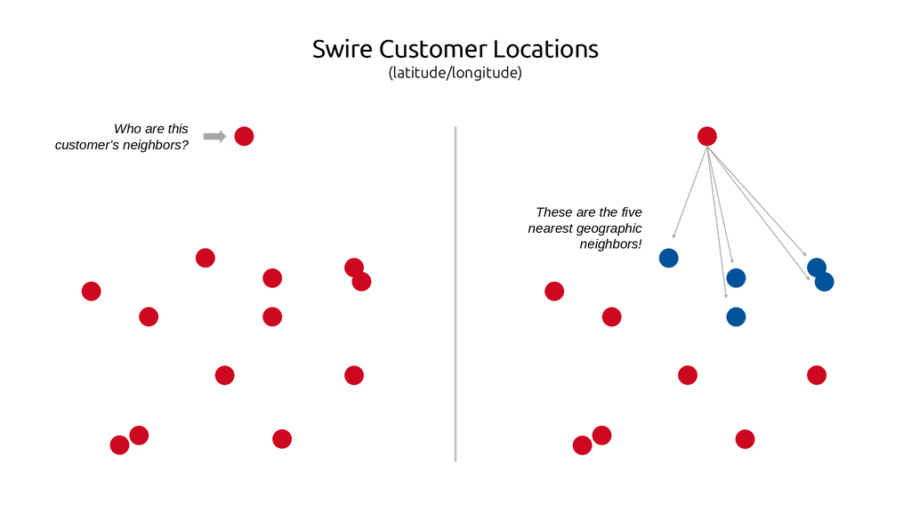

For each customer, it may be helpful to know how isolated or densely populated they are. We can approximate this using the “Haversine Distance” formula. In short, it utilizes the latitude and longitude, adjusting for eath’s curvature, to approximate the “as the crow flies” distance.

Knowing which 5 customers are closest to each, we can determine order volume, return rates, etc., for these neighbors. **These fields could be helpful in determining the value of an area**; if an area is valuable, even if the customer isn’t *yet*, there may be a statistical argument for their potential for red truck.

Let’s derive these distances.

### Data Prep

#### Customer Level of Detail

We want to get the data to one customer per row. Since we’re currently at the level of detail of transactions, we need to do some prep work.

```r
swire_cust_grp <-
    swire_data_full |>
    group_by(
        pick(customer_number:lon, return_frequency, year)  # Dynamically select grouping vars from a range and specific columns
    ) |>
    summarise(
        order_transactions = sum(ifelse(ordered_total > 0, 1, 0)),  # Count orders with any volume
        order_transaction_std = sd(ordered_total),  # Standard deviation of order volumes
        delivery_transactions = sum(ifelse(delivered_total > 0, 1, 0)),  # Count deliveries with any volume
        across(
            ordered_cases:delivered_total,
            ~ sum(.x)  # Sum volume fields across all grouped records
        )
    ) |>
    ungroup()
```

[output not shown]

```r
swire_cust_uniq <-
    swire_cust_grp |>
    pivot_wider(
        id_cols = c(customer_number:primary_group_number, on_boarding_date:lon),  # Keep customer and location details as IDs
        names_from = year,  # Create wide columns based on year
        values_from = c(primary_group_customers, return_frequency:delivered_total),  # Use these variables as values
        names_glue = "{.value}_{year}",  # Name columns with value + year suffix
        values_fill = 0  # Fill missing values with 0 for all widened fields
    )

swire_cust_clean <-
    swire_cust_uniq |>
    replace_na(list(
        order_transaction_std_2023 = mean(swire_cust_uniq$order_transaction_std_2023, na.rm = TRUE),  # Replace NA with column mean
        order_transaction_std_2024 = mean(swire_cust_uniq$order_transaction_std_2024, na.rm = TRUE),
        delivered_gallons_cost_2023 = 0,  # Explicitly set NA cost fields to 0
        delivered_gallons_cost_2024 = 0,
        delivered_cases_cost_2023 = 0,
        delivered_cases_cost_2024 = 0
    )) |>
    select(-c(city, zip, state_abbr, county))  # Remove unneeded location granularity
```

#### Distance Calculations

```r
if(file.exists('data/derived/cust_dist.rda')) {
    load('data/derived/cust_dist.rda')  # Load precomputed customer distance data if available
} else {
    kansas.data <- swire_cust_grp |> filter(state == 'Kansas')  # Filter for customers within each state
    kansas.dist <- distm(kansas.data[,c("lon", "lat")], fun = distHaversine)  # Compute pairwise Haversine distances

    mass.data <- swire_cust_grp |> filter(state == 'Massachusetts')
    mass.dist <- distm(mass.data[,c("lon", "lat")], fun = distHaversine)

    maryland.data <- swire_cust_grp |> filter(state == 'Maryland')
    maryland.dist <- distm(maryland.data[,c("lon", "lat")], fun = distHaversine)

    kentucky.data <- swire_cust_grp |> filter(state == 'Kentucky')
    kentucky.dist <- distm(kentucky.data[,c("lon", "lat")], fun = distHaversine)

    louisiana.data <- swire_cust_grp |> filter(state == 'Louisiana')
    louisiana.dist <- distm(louisiana.data[,c("lon", "lat")], fun = distHaversine)

    cust_dist <- list(
        "louisiana" = list(
            "dist" = louisiana.dist,  # Distance matrix
            "cust" = louisiana.data$customer_number,  # Customer IDs
            "group" = louisiana.data$primary_group_number  # Group IDs
        ),
        "kansas" = list(
            "dist" = kansas.dist,
            "cust" = kansas.data$customer_number,
            "group" = kansas.data$primary_group_number
        ),
        "mass" = list(
            "dist" = mass.dist,
            "cust" = mass.data$customer_number,
            "group" = mass.data$primary_group_number
        ),
        "maryland" = list(
            "dist" = maryland.dist,
            "cust" = maryland.data$customer_number,
            "group" = maryland.data$primary_group_number
        ),
        "kentucky" = list(
            "dist" = kentucky.dist,
            "cust" = kentucky.data$customer_number,
            "group" = kentucky.data$primary_group_number
        )
    )

    save(cust_dist, file = "data/cust_dist.rda")  # Save list for future reuse
}
```

```r
# Replace diagonals in each matrix
diag(cust_dist$louisiana$dist) <- Inf
diag(cust_dist$kansas$dist) <- Inf
diag(cust_dist$mass$dist) <- Inf
diag(cust_dist$maryland$dist) <- Inf
diag(cust_dist$kentucky$dist) <- Inf
```

```r
get_top5 <- function(row) {
    idx <- order(setdiff(row, c(0)))[1:5]  # Get indices of 5 smallest non-zero values
    values <- row[idx] / 1000  # Scale selected values (e.g., convert meters to kilometers)
    list(indices = idx, values = values)  # Return both positions and scaled values
}
```

```r
# Initialize empty results data frame with correct types
dist_df <- data.frame(matrix(NA, nrow = 0, ncol = 4)) |>
    mutate(
        X1 = as.character(X1),  # Placeholder for customer_number
        X2 = as.character(X2),  # Placeholder for primary_group_number
        X3 = as.integer(X3),    # Placeholder for indices
        X4 = as.numeric(X4)     # Placeholder for distances
    )
colnames(dist_df) <- c("customer_number", "primary_group_number", "indices", "distances")

# Iterate through each state’s distance list
for(state in names(cust_dist)) {
    results <- apply(cust_dist[[state]]$dist, 1, get_top5)  # Get top 5 closest neighbors for each customer

    results_tbl <- tibble(
        customer_number = as.character(cust_dist[[state]]$cust),  # Focal customer ID
        primary_group_number = as.character(cust_dist[[state]]$group),  # Customer's group
        indices = lapply(results, function(x) x$indices),  # List of nearest neighbor indices
        distances = lapply(results, function(x) x$values)  # List of corresponding distances
    ) |>
        unnest_longer(c("indices", "distances")) |>  # Expand each row to one row per neighbor
        inner_join(
            tibble(
                neighbor_number = as.character(cust_dist[[state]]$cust)  # Lookup table for matching index to customer ID
            ) |> rowid_to_column(),  # Add index for join (1-based row index)
            join_by(indices == rowid)  # Match neighbor index to actual customer ID
        )

    dist_df <- bind_rows(dist_df, results_tbl)  # Append results to final data frame
}
```

#### Intersecting With Customers

Now that we have generated the “neighbors” for each customer, we can join back to our cleaned customer data and calculate summary values for all of the neighbors.

```r
customer_neighbors <- dist_df |>
    as_tibble() |>
    inner_join(
        swire_cust_clean,  # Join neighbor details from customer-level data
        join_by(neighbor_number == customer_number)
    ) |>
    mutate(
        same_group_flg = primary_group_number.x == primary_group_number.y  # Flag if neighbor is in same group
    ) |>
    group_by(customer_number) |>
    summarise(
        neighbor_avg_dist_km = mean(distances),  # Avg distance to neighbors (in km)
        neighbor_primary_group_count = sum(same_group_flg, na.rm = TRUE),  # Count of neighbors in same group
        neighbor_local_market_partners = sum(local_market_partner),  # Number of neighbors that are LMP
        neighbor_avg_return_freq = (mean(return_frequency_2023) + mean(return_frequency_2024)) / 2,  # Avg return frequency across years
        neighbor_avg_order_transactions_2023 = mean(order_transactions_2023),
        neighbor_avg_order_transactions_2024 = mean(order_transactions_2024),
        neighbor_avg_order_transaction_std_2023 = mean(order_transaction_std_2023),
        neighbor_avg_order_transaction_std_2024 = mean(order_transaction_std_2024),
        neighbor_avg_ordered_total_2023 = mean(ordered_total_2023),
        neighbor_avg_ordered_total_2024 = mean(ordered_total_2024)
    ) |>
    ungroup()

customer_neighbor_fields <-
    customer_neighbors |>
    mutate(
        neighbor_avg_dist_km = ifelse(
            is.infinite(neighbor_avg_dist_km),
            max(ifelse(!is.infinite(neighbor_avg_dist_km), neighbor_avg_dist_km, NA), na.rm = TRUE),  # Replace Inf with max finite distance
            neighbor_avg_dist_km
        )
    ) |>
    replace_na(list(
        neighbor_avg_dist_km = median(customer_neighbors$neighbor_avg_dist_km, na.rm = TRUE),  # Replace NA with median
        neighbor_avg_order_transaction_std_2023 = mean(customer_neighbors$neighbor_avg_order_transaction_std_2023, na.rm = TRUE),
        neighbor_avg_order_transaction_std_2024 = mean(customer_neighbors$neighbor_avg_order_transaction_std_2024, na.rm = TRUE)
    ))
```

#### Enriching Additional Values

We now gave great summary values for the neighbors of each customer. Let’s now get our full customer level of detail data together and finalize some data enrichment:

```r
swire_cust_enriched <-
    swire_cust_clean |>
    inner_join(customer_neighbor_fields) |>  # Join with neighbor feature set
    mutate(
        across(c(on_boarding_date, first_delivery_date), as.Date),  # Ensure proper date format
        across(c(customer_number, primary_group_number), as.character),  # Convert IDs to character
        across(c(co2_customer, local_market_partner), as.integer),  # Convert logicals to integers for modeling
        customer_tenure_yrs = round(as.integer(lubridate::ymd("2024-12-31") - first_delivery_date) / 365.25, 1),  # Tenure as of end of 2024
        ramp_up_mon = round(as.integer(first_delivery_date - on_boarding_date) * 12 / 365.25, 1),  # Months between onboarding and first delivery
        annual_total = (ordered_total_2023 + ordered_total_2024) / 2,  # 2-year average of total ordered
        avg_transaction_amt = ifelse(
            (order_transactions_2023 + order_transactions_2024) <= 0, 0,  # Avoid division by 0
            (ordered_total_2023 + ordered_total_2024) / (order_transactions_2023 + order_transactions_2024)  # Avg order size
        ),
        avg_neighbor_transaction_amt = (neighbor_avg_ordered_total_2023 + neighbor_avg_ordered_total_2024) /
                                       (neighbor_avg_order_transactions_2023 + neighbor_avg_order_transactions_2024)  # Peer group avg
    ) |>
    select(-c(on_boarding_date, first_delivery_date))  # Drop raw dates now that derived fields are created
```

We now have a really feature rich dataset with additional features describing the area and neighboring customers.

```r
glimpse(swire_cust_enriched)
```

```
Rows: 30,322
Columns: 60
$ customer_number                         <chr> "500245678", "500245685", "500…
$ primary_group_number                    <chr> NA, NA, "8333", NA, NA, "2272"…
$ cold_drink_channel                      <fct> EVENT, DINING, GOODS, EVENT, D…
$ frequent_order_type                     <fct> SALES REP, OTHER, CALL CENTER,…
$ trade_channel                           <fct> OUTDOOR ACTIVITIES, FAST CASUA…
$ sub_trade_channel                       <fct> OTHER OUTDOOR ACTIVITIES, PIZZ…
$ local_market_partner                    <int> 1, 1, 1, 1, 1, 1, 1, 0, 1, 1, …
$ co2_customer                            <int> 1, 1, 0, 1, 0, 1, 1, 0, 1, 0, …
$ state                                   <fct> Kansas, Maryland, Massachusett…
$ lat                                     <dbl> 39.8428, 39.4015, 42.7215, 37.…
$ lon                                     <dbl> -96.6422, -75.8654, -72.9762, …
$ primary_group_customers_2023            <dbl> 0, 0, 11, 0, 0, 8, 0, 21, 0, 5…
$ primary_group_customers_2024            <dbl> 0, 0, 11, 0, 0, 8, 0, 25, 0, 6…
```

[output cut: 47 more lines]

#### Prep for Clustering

We need to turn categorical data into one-hot encoded (dummy) variables so we can run PCA.

```r
swire_numeric <- swire_cust_enriched |>
    select(where(is.numeric))  # Select all numeric columns for modeling or analysis

swire_non_numeric <- swire_cust_enriched |>
    select(!where(is.numeric)) |>  # Select all non-numeric columns
    select(-c(customer_number, primary_group_number, sub_trade_channel)) |>  # Drop ID fields and sub_trade_channel
    mutate(
        across(everything(), ~factor(make.names(.)))  # Standardize values (safe for model.matrix) and convert to factors
    )
```

```r
# Create dummy variables for non-numeric features
swire_dmy <- dummyVars("~ .", swire_non_numeric)
data_dmy <- data.frame(predict(swire_dmy, swire_non_numeric))
```

```r
swire_cust_combined <-
    swire_numeric |>
    bind_cols(data_dmy) |>  # Combine numeric fields with dummy-coded categorical variables
    select(-c(trade_channel.PHARMACY.RETAILER))  # Drop a specific one-hot encoded column, likely due to collinearity
```

Let’s now scale these values:

```r
swire_scaled <- scale(swire_cust_combined)
```

Let’s run PCA and get a sense for how well it does:

```r
swire_pca <- prcomp(swire_scaled)
```

```r
summary(swire_pca)
```

```
Importance of components:
                          PC1     PC2     PC3     PC4     PC5     PC6     PC7
Standard deviation     4.0541 2.82661 2.12820 2.01993 1.81886 1.75405 1.68203
Proportion of Variance 0.1677 0.08153 0.04622 0.04163 0.03376 0.03139 0.02887
Cumulative Proportion  0.1677 0.24924 0.29546 0.33709 0.37085 0.40224 0.43111
                           PC8     PC9   PC10    PC11    PC12    PC13    PC14
Standard deviation     1.49076 1.47696 1.4449 1.42618 1.42530 1.35762 1.32263
Proportion of Variance 0.02268 0.02226 0.0213 0.02075 0.02073 0.01881 0.01785
Cumulative Proportion  0.45379 0.47605 0.4974 0.51811 0.53884 0.55764 0.57549
                          PC15    PC16    PC17    PC18    PC19    PC20    PC21
Standard deviation     1.30013 1.28161 1.24584 1.21431 1.13821 1.11259 1.08661
Proportion of Variance 0.01725 0.01676 0.01584 0.01505 0.01322 0.01263 0.01205
Cumulative Proportion  0.59274 0.60950 0.62534 0.64039 0.65361 0.66624 0.67829
                          PC22    PC23    PC24    PC25    PC26   PC27    PC28
Standard deviation     1.08291 1.05625 1.04726 1.04526 1.04139 1.0336 1.03109
Proportion of Variance 0.01197 0.01138 0.01119 0.01115 0.01107 0.0109 0.01085
Cumulative Proportion  0.69025 0.70164 0.71283 0.72398 0.73504 0.7460 0.75679
                          PC29    PC30    PC31    PC32    PC33    PC34    PC35
Standard deviation     1.02453 1.02154 1.01088 1.00860 1.00526 1.00336 1.00114
Proportion of Variance 0.01071 0.01065 0.01043 0.01038 0.01031 0.01027 0.01023
Cumulative Proportion  0.76750 0.77815 0.78858 0.79896 0.80927 0.81954 0.82977
                          PC36    PC37    PC38    PC39    PC40   PC41    PC42
Standard deviation     0.99951 0.99632 0.99438 0.99284 0.98189 0.9752 0.95793
Proportion of Variance 0.01019 0.01013 0.01009 0.01006 0.00984 0.0097 0.00936
Cumulative Proportion  0.83997 0.85010 0.86019 0.87024 0.88008 0.8898 0.89915
                          PC43    PC44    PC45    PC46    PC47    PC48    PC49
Standard deviation     0.95111 0.92400 0.91676 0.86797 0.84328 0.81402 0.80134
Proportion of Variance 0.00923 0.00871 0.00858 0.00769 0.00726 0.00676 0.00655
Cumulative Proportion  0.90838 0.91709 0.92567 0.93336 0.94061 0.94737 0.95393
                          PC50    PC51    PC52   PC53    PC54    PC55    PC56
Standard deviation     0.72398 0.68060 0.66692 0.6490 0.61090 0.56615 0.54297
Proportion of Variance 0.00535 0.00473 0.00454 0.0043 0.00381 0.00327 0.00301
Cumulative Proportion  0.95928 0.96400 0.96854 0.9728 0.97665 0.97992 0.98293
                          PC57    PC58    PC59    PC60    PC61   PC62    PC63
Standard deviation     0.51848 0.47066 0.42647 0.42059 0.38251 0.3702 0.32997
Proportion of Variance 0.00274 0.00226 0.00186 0.00181 0.00149 0.0014 0.00111
Cumulative Proportion  0.98567 0.98793 0.98979 0.99159 0.99308 0.9945 0.99559
                         PC64    PC65    PC66    PC67    PC68    PC69    PC70
Standard deviation     0.2976 0.28284 0.23624 0.21371 0.20487 0.16355 0.14185
Proportion of Variance 0.0009 0.00082 0.00057 0.00047 0.00043 0.00027 0.00021
Cumulative Proportion  0.9965 0.99731 0.99788 0.99835 0.99878 0.99905 0.99926
                          PC71    PC72    PC73    PC74    PC75    PC76    PC77
Standard deviation     0.13746 0.12848 0.10599 0.09719 0.06102 0.05779 0.04836
Proportion of Variance 0.00019 0.00017 0.00011 0.00010 0.00004 0.00003 0.00002
Cumulative Proportion  0.99945 0.99962 0.99973 0.99983 0.99987 0.99990 0.99992
                          PC78    PC79    PC80    PC81    PC82    PC83    PC84
Standard deviation     0.03927 0.03897 0.03207 0.03040 0.02616 0.02222 0.02137
Proportion of Variance 0.00002 0.00002 0.00001 0.00001 0.00001 0.00001 0.00000
Cumulative Proportion  0.99994 0.99996 0.99997 0.99998 0.99998 0.99999 0.99999
                          PC85    PC86    PC87      PC88      PC89      PC90
Standard deviation     0.01996 0.01598 0.01261 2.736e-14 1.787e-14 7.848e-15
Proportion of Variance 0.00000 0.00000 0.00000 0.000e+00 0.000e+00 0.000e+00
Cumulative Proportion  1.00000 1.00000 1.00000 1.000e+00 1.000e+00 1.000e+00
                            PC91      PC92      PC93      PC94      PC95
Standard deviation     6.736e-15 5.985e-15 4.242e-15 3.289e-15 2.059e-15
Proportion of Variance 0.000e+00 0.000e+00 0.000e+00 0.000e+00 0.000e+00
Cumulative Proportion  1.000e+00 1.000e+00 1.000e+00 1.000e+00 1.000e+00
                            PC96      PC97      PC98
Standard deviation     1.814e-15 7.947e-16 5.483e-16
Proportion of Variance 0.000e+00 0.000e+00 0.000e+00
Cumulative Proportion  1.000e+00 1.000e+00 1.000e+00
```

With only 33 principal components, we’re capturing 80% of the variability. This is probably sufficient for us to proceed.

```r
swire_pca_results <- as.data.frame(swire_pca$x)
```

#### Clustering Algorithm Setup

We’re going to try two different algorithms: `kmeans` and `hierarchical` clustering. We’ll setup two functions that will calculate the within sum of squares (`wss`).

```r
cluster_kmeans <- function(k, data) {
    fit <- kmeans(data, k)  # Run k-means clustering with k clusters
    vals <- glance(fit)  # Get summary metrics
    return(vals$tot.withinss)  # Return total within-cluster sum of squares
}

cluster_hclust <- function(k, data) {
    # Initialize hierarchical clustering model with complete linkage
    model <- hier_clust(num_clusters = k, linkage_method = "complete")

    # Fit the model to the data
    fit <- model |> fit(~., data = as.data.frame(data))

    # Compute and return the total within-cluster sum of squares
    wss <- fit |>
        sse_within() |>  # Compute WSS for each cluster
        select(wss) |>  # Extract WSS column
        unlist() |>  # Convert to a vector
        sum()  # Total WSS
    return(wss)
}
```

Let’s setup a grid where we can save different values for these algorithms against different cluster sizes (2-8) and WSS values:

```r
set.seed(814)  # Ensure reproducibility for sampling and clustering

swire_pca_80 <- swire_pca_results[,1:33]  # Select first 33 PCs explaining ~80% variance
swire_pca_80_sampl <- swire_pca_80 |> sample_n(size = 5000)  # Randomly sample 5,000 rows for faster clustering

clustering_grid <- data.frame(
    clusters = 2:8  # Define range of cluster counts to evaluate
)
```

We’ve also taken a sample of the data for computational efficiency. Let’s use a function to plot the outcomes:

```r
show_cluster_results <- function(results, title) {
    results |>
        pivot_longer(cols = -clusters) |>  # Reshape to long format for ggplot
        unnest(value) |>  # Expand list-columns (if results are stored that way)
        ggplot(aes(
            factor(clusters),  # X-axis: number of clusters (as a factor for discrete spacing)
            as.numeric(value),  # Y-axis: WSS values
            group = name  # Group by clustering method
        )) +
        geom_line(
            color = swire_colors$red,  # Dotted red line for visual reference
            linetype = "dotted",
            size = 2
        ) +
        geom_smooth(
            aes(group = name),
            color = swire_colors$red,
            se = FALSE  # Add smoothed trend line, no confidence band
        ) +
        labs(
            title = title,
            subtitle = "Two clustering algorithm methods: kmeans and hierarchical",
            x = "Number of clusters",
            y = "Within Sum of Squares"
        ) +
        facet_wrap(~name, ncol = 1, scales = "free") +  # Separate plots for each method
        theme_swire()
}
```

#### Clustering Exploration

```r
clustering_grid_results_sampl_80 <-
    clustering_grid |>
    mutate(
        kmeans = map(clusters, ~ cluster_kmeans(.x, swire_pca_80_sampl)),  # Compute WSS for k-means at each k
        hclust = map(clusters, ~ cluster_hclust(.x, swire_pca_80_sampl))   # Compute WSS for hierarchical clustering at each k
    )
```

```r
show_cluster_results(
    clustering_grid_results_sampl_80
    , "Cluster Results | 80% PCA, 5K Sample"
)
```

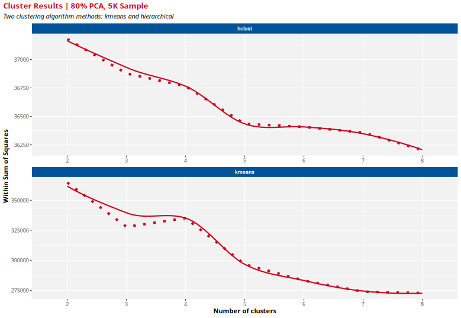

This graph gives us a sense for the “elbow point”, the crux where we get diminishing returns in WSS from splitting into more and more clusters.

```r
clustering_grid_results_80 <-
    clustering_grid |>
    mutate(
        kmeans = map(clusters, ~ cluster_kmeans(.x, swire_pca_80)),  # Run k-means clustering on full PCA dataset
        hclust = map(clusters, ~ cluster_hclust(.x, swire_pca_80))   # Run hierarchical clustering on full PCA dataset
    )
```

```r
show_cluster_results(
    clustering_grid_results_80
    , "Cluster Results | 80% PCA, All Data"
)
```

[output not shown]

Let’s generate cluster assignments!

#### Cluster Assignments

```r
# Derive fitted cluster assignments from hierarchical approach
model <- hier_clust(num_clusters = 5, linkage_method = "complete")
fit <- model |> fit(~., data = swire_pca_80)

# Next this
cluster_assignments <- fit |> predict(swire_pca_80)
```

Now let’s join those cluster assignments back to our original, enriched data set. This will allow us to explore the properties of each cluster.

```r
swire_cust_clustered <- swire_cust_enriched |> mutate(cluster = cluster_assignments$.pred_cluster)
```

#### Cluster Evaluation

Now, let’s evaluate the results, starting with how many customers are in each cluster:

```r
swire_cust_clustered |>
  group_by(cluster) |>
  count()
```

```
# A tibble: 5 × 2
# Groups:   cluster [5]
  cluster       n
  <fct>     <int>
1 Cluster_1 30281
2 Cluster_2    12
3 Cluster_3    26
4 Cluster_4     2
5 Cluster_5     1
```

We can do a lot more, like describe the unique attributes of each. For now, this is all we have time for.

### Future Improvements

A big part of clustering is learning about what is driving the assignment. In so doing, we’ll gain insight about the fields that best describe the cluster. Those insights will help us name the clusters, bringing them to life in a powerful way for viewing the business.

This is the next, crucial step. In its current form, the clusters are meaningless. Despite lacking time to do this piece for this milestone, it’s a top priority in the early stages of preparing a presentation.

## Approach 3: Zac

### Data Prep

```r
# Data Cleaning & Aggregation
transactional_df <- transactions %>%
  clean_names() %>%  # Standardize column names to snake_case
  mutate(
    transaction_date = ymd(transaction_date),  # Parse transaction dates
    customer_number = as.character(customer_number)  # Ensure consistent ID type
  ) %>%
  group_by(customer_number) %>%
  summarise(
    total_ordered_cases = sum(ordered_cases, na.rm = TRUE),
    total_delivered_cases = sum(delivered_cases, na.rm = TRUE),
    net_delivered_cases = sum(ifelse(delivered_cases < 0, 0, delivered_cases), na.rm = TRUE),  # Set negatives to 0
    fulfillment_rate = ifelse(total_ordered_cases == 0, NA, net_delivered_cases / total_ordered_cases),  # Prevent division by 0
    total_returned_cases = sum(abs(delivered_cases[delivered_cases < 0]), na.rm = TRUE),  # Sum of negative case volumes
    total_ordered_gallons = sum(ordered_gallons, na.rm = TRUE),
    total_delivered_gallons = sum(delivered_gallons, na.rm = TRUE),
    net_delivered_gallons = sum(ifelse(delivered_gallons < 0, 0, delivered_gallons), na.rm = TRUE),  # Remove negative gallon values
    fulfillment_rate_gallons = ifelse(total_ordered_gallons == 0, NA, net_delivered_gallons / total_ordered_gallons),
    total_returned_gallons = sum(abs(delivered_gallons[delivered_gallons < 0]), na.rm = TRUE)
  ) %>%
  filter(!is.na(fulfillment_rate) & !is.na(fulfillment_rate_gallons))  # Keep only customers with valid data
# Clustering (4 Clusters)
set.seed(123)  # Reproducibility

clustering_data <- transactional_df %>%
  select(
    total_ordered_cases, total_delivered_cases, fulfillment_rate,
    total_ordered_gallons, total_delivered_gallons, fulfillment_rate_gallons
  ) %>%
  scale()  # Standardize for k-means

kmeans_model <- kmeans(clustering_data, centers = 4, nstart = 10)  # Run k-means with 4 clusters
transactional_df$cluster <- kmeans_model$cluster  # Assign cluster labels to original data
```

### Fulfillment Clustering

Data was transformed in the clustering process to determine fulfillment rate for gallons and cases (gallons and cases ordered vs what was delivered). This transactional data was then fitting into a clustering model. For time saving in knitting and processing, optimal clustering process was left off from here but determined to be in the 4 to 5 range.

After clustering the first time, cluster 4 was removed as that data seemed erroneous and simply a data issue. Then I ran clustering for 5.

Results:

```r
# Results and Key Takeaways
transactional_df <- transactional_df %>% filter(cluster != 4)
clustering_data <- transactional_df %>% select(-customer_number) %>% scale()
kmeans_model <- kmeans(clustering_data, centers = 5, nstart = 10)
transactional_df$cluster <- kmeans_model$cluster

# Summarize new clusters
transactional_df %>%
  group_by(cluster) %>%
  summarise(
    avg_ordered = mean(total_ordered_cases, na.rm = TRUE),
    avg_delivered = mean(total_delivered_cases, na.rm = TRUE),
    avg_fulfillment_rate = mean(fulfillment_rate, na.rm = TRUE),
    count = n()
  )
```

```
# A tibble: 5 × 5
  cluster avg_ordered avg_delivered avg_fulfillment_rate count
    <int>       <dbl>         <dbl>                <dbl> <int>
1       1       2840.         2501.                0.714   132
2       2      19428.        18249.                0.954    45
3       3     653502.       623026.                0.953     2
4       4       2713.         2537.                0.748   496
5       5          2           412.              206.        1
```

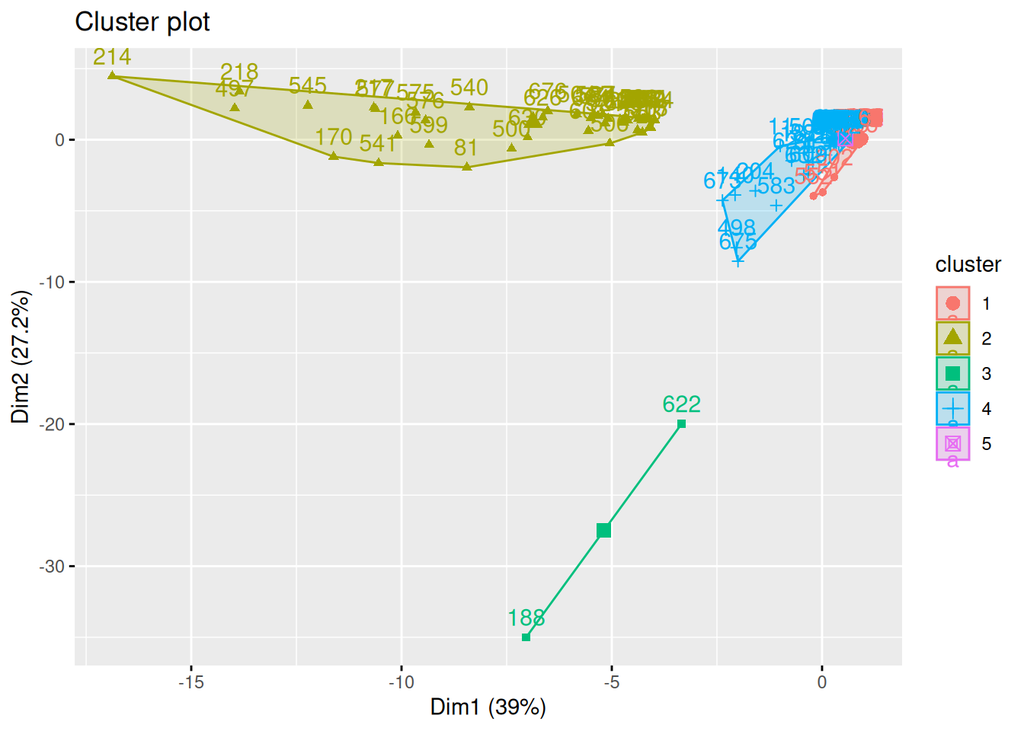

```r
# Visualize clusters
fviz_cluster(kmeans_model, data = clustering_data)
```

```r
# Display results
cluster_summary <- tibble(
  Cluster = c("Cluster 1", "Cluster 2", "Cluster 3", "Cluster 4", "Cluster 5"),
  Avg_Ordered = c(1.92, 186452.9, 978.69, 56778.0, 472528.8),
  Avg_Delivered = c(75.77, 177788.6, 908.96, 53204.9, 455473.8),
  Avg_Fulfillment_Rate = c(43.07, 0.95, 0.96, 0.94, 0.96),
  Count = c(39, 22, 24298, 128, 8),
  Interpretation = c(
    "Very small orders, possibly misclassified or extreme cases",
    "Large volume buyers (high-end distributors)",
    "Typical small/medium business buyers",
    "Medium-volume corporate buyers",
    "Elite large buyers (possibly wholesalers)"
  )
)
print(kable(cluster_summary, caption = "Cluster Summary Table"))
```

[output not shown]

### Clustered Fulfillment Rate Summary

#### Extract Gallons and Cases Customers from Cluster Three for Summary

```r
# Extract Gallons and Cases Customers from Cluster Three

cluster_3_customers <- transactional_df %>% filter(cluster == 3)

cluster_3_cases <- cluster_3_customers %>%
  select(customer_number, total_ordered_cases, total_delivered_cases, fulfillment_rate, total_returned_cases) %>%
  filter(!is.na(fulfillment_rate)) %>%
  arrange(desc(fulfillment_rate))

cluster_3_gallons <- cluster_3_customers %>%
  select(customer_number, total_ordered_gallons, total_delivered_gallons, fulfillment_rate_gallons, total_returned_gallons) %>%
  filter(!is.na(fulfillment_rate_gallons)) %>%
  arrange(desc(fulfillment_rate_gallons))

print(head(cluster_3_cases))
```

```
# A tibble: 2 × 5
  customer_number total_ordered_cases total_delivered_cases fulfillment_rate
  <chr>                         <dbl>                 <dbl>            <dbl>
1 501267499                   835642.               798259.            0.955
2 600265975                   471362                447792.            0.950
# ℹ 1 more variable: total_returned_cases <dbl>
```

```r
print(head(cluster_3_gallons))
```

```
# A tibble: 2 × 5
  customer_number total_ordered_gallons total_delivered_gallons
  <chr>                           <dbl>                   <dbl>
1 501267499                        72.5                    72.5
2 600265975                       652.                    617.
# ℹ 2 more variables: fulfillment_rate_gallons <dbl>,
#   total_returned_gallons <dbl>
```

### Insights

To analyze their fulfillment patterns, I split this cluster into two separate datasets:

- Gallons Dataset – Includes customer fulfillment rate in gallons along with their returns.
- Cases Dataset – Includes customer fulfillment rate in cases along with their returns.

By leveraging this clustered fullfillment information, Swire’s sales team can identify customers who are selling more than they order and prioritize those with the highest potential for growth. This allows them to focus time and resources on businesses that would benefit from additional support, ultimately strengthening customer relationships and increasing sales opportunities.

### Future Improvements

While the clustered fulfillment model offers insights into high-performing and high-potential customers, identifying individual customers would provide additional value for salespeople and other points of contact who have direct relationships with them. Their personal experience could help interpret the data more effectively. Additionally, incorporating features that classify customers by business type could enhance clustering, offering more precise insights into fulfillment rates across different industries.

## Approach 4: Georgia

##### Forecasting Data Preparation

Since XGBoost requires numerical values, all categorical variables were turned into factors so they could be encoded later. Columns I thought were unnecessary were removed to simplify the dataset. To help the model recognize patterns, several new features were added. Date-based features like week, month, and quarter were created to help capture seasonal trends. Lag features (lag_1, lag_4, lag_6) were added to give the model information about recent orders, helping it detect short-term changes. Rolling averages (rolling_avg_3 and rolling_avg_6) were included to smooth out order patterns and reduce noise, and a growth_rate feature was added to measure customer momentum by comparing recent orders to past orders. To better predict behavior for different customer types, a new_customer flag was created to separate new customers from established ones to help the model handle each group’s unique behaviors.

```r
data <- as.data.table(swire_data_full)
neighbors <- customer_neighbor_fields

# convert character variables to factor
cols <- names(data)[sapply(data, is.character)]
data[, (cols) := lapply(.SD, as.factor), .SDcols = cols]

# remove primary group number
data <- subset(data, select = -primary_group_number)

# add a "week" and "month" column
data$transaction_week <- floor_date(data$transaction_date, unit = "week")
data$transaction_month <- floor_date(data$transaction_date, unit = "month")

# convert to data table
setDT(data)

# join neighbors data
data <- data[neighbors, on = "customer_number"]

# aggregate to weekly transactions by customer for all customers
df_grouped_week <- data[, .(
  weekly_ordered_total   = sum(ordered_total, na.rm=TRUE),
  weekly_delivered_total = sum(delivered_total, na.rm=TRUE)#,
  #weekly_return_freq     = sum(return_frequency, na.rm=TRUE)
), by = .(transaction_week, customer_number)]

# subset data
features <- data[, .(customer_number, on_boarding_date, first_delivery_date, cold_drink_channel, frequent_order_type, trade_channel, sub_trade_channel, neighbor_avg_dist_km, neighbor_primary_group_count, neighbor_avg_return_freq, neighbor_local_market_partners, neighbor_avg_order_transactions_2023, neighbor_avg_order_transactions_2024, neighbor_avg_order_transaction_std_2023, neighbor_avg_order_transaction_std_2024, neighbor_avg_ordered_total_2023, neighbor_avg_ordered_total_2024)]

# get unique features
features <- unique(features)

# create a full set of weeks for each customer - all customers
date_seq_all <- df_grouped_week[, .(transaction_week = seq(min(transaction_week),
                                                   max(transaction_week),
                                                   by = "week")),
                        by = customer_number]

# merge back with original data
df_grouped_week <- merge(date_seq_all, df_grouped_week,
                     by = c("customer_number", "transaction_week"),
                     all.x = TRUE)

# fill missing weeks with zero orders
df_grouped_week[is.na(weekly_ordered_total), weekly_ordered_total := 0]
df_grouped_week[is.na(weekly_delivered_total), weekly_delivered_total := 0]
#df_grouped_week[is.na(weekly_return_freq), weekly_return_freq := 0]

# join the rest of the variables for all customers
df_grouped_week <- merge(df_grouped_week, features, by = "customer_number", all = TRUE)
```

##### Feature Engineering

```r
# newer vs. existing customers using first delivery date
# new vs. existing cutoff
cutoff_date <- as.IDate("2023-07-01")

# create a logical flag
df_grouped_week[, new_customer := (first_delivery_date >= cutoff_date)]

# add date-based features
df_grouped_week[, month := month(transaction_week)]
df_grouped_week[, quarter := quarter(transaction_week)]

# sort to chronological order
setorder(df_grouped_week, customer_number, transaction_week)

# add Lag Features
df_grouped_week[, lag_1 := shift(weekly_ordered_total, 1), by = customer_number]
df_grouped_week[, lag_4 := shift(weekly_ordered_total, 4), by = customer_number]
df_grouped_week[, lag_6 := shift(weekly_ordered_total, 6), by = customer_number]

# add Rolling Averages
df_grouped_week[, rolling_avg_3 := frollmean(weekly_ordered_total, 3), by = customer_number]
df_grouped_week[, rolling_avg_6 := frollmean(weekly_ordered_total, 6), by = customer_number]

# time since onboarding
df_grouped_week[, time_since_onboarding_weeks :=
  as.numeric(difftime(transaction_week, on_boarding_date, units = "weeks"))]
df_grouped_week[time_since_onboarding_weeks < 0, time_since_onboarding_weeks := 0]

# growth rate calculation
df_grouped_week[, growth_rate := (weekly_ordered_total - shift(weekly_ordered_total, 4)) /
                                      shift(weekly_ordered_total, 4), by = customer_number]

# replace infinite or NA values with zero
df_grouped_week[is.infinite(growth_rate) | is.na(growth_rate), growth_rate := 0]
```

##### Create train and test data - Older Customers

```r
# split data based on time
train <- df_grouped_week[new_customer == FALSE & transaction_week < "2024-7-1"]
test  <- df_grouped_week[new_customer == FALSE & transaction_week >= "2024-7-1"]

y_train <- train$weekly_ordered_total
y_test <- test$weekly_ordered_total

train[, week_of_year := week(transaction_week)]
train[, month := month(transaction_week)]
train[, quarter := quarter(transaction_week)]
train[, year := year(transaction_week)]

test[, week_of_year := week(transaction_week)]
test[, month := month(transaction_week)]
test[, quarter := quarter(transaction_week)]
test[, year := year(transaction_week)]

exclude_cols <- c("customer_number", "weekly_ordered_total", "first_delivery_date", "transaction_week", "on_boarding_date", "weekly_delivered_total")
test_id_table <- test[, .(customer_number, transaction_week, weekly_ordered_total)]
cat_features <- names(train)[sapply(train, is.factor) | sapply(train, is.character)]

# dummy encode categorical variables and remove target and identifier vars
x_train <- train[, setdiff(names(train), exclude_cols), with = FALSE]
x_train <- dummy_cols(x_train, select_columns = cat_features, remove_selected_columns = TRUE)
# dummy encode test data and remove target and identifier vars
x_test <- test[, setdiff(names(train), exclude_cols), with = FALSE]
x_test <- dummy_cols(x_test, select_columns = cat_features, remove_selected_columns = TRUE)
# convert to matrix
x_train <- as.matrix(x_train)
x_test <- as.matrix(x_test)

# Convert Data to DMatrix Format
dtrain <- xgb.DMatrix(data = x_train, label = y_train, missing = NA)
dtest  <- xgb.DMatrix(data = x_test, label = y_test, missing = NA)
```

##### Model Training - Older Customers

```r
params_reg <- list(
  objective = "reg:squarederror",
  eta = 0.1,
  max_depth = 6,
  min_child_weight = 5,
  subsample = 0.8,
  colsample_bytree = 0.7,
  reg_alpha = 0.3,        # add L1 regularization
  reg_lambda = 1,         # add L2 regularization
  eval_metric = c("rmse", "mae")
)

model <- xgb.train(
  params = params_reg,
  data = dtrain,
  nrounds = 500,
  watchlist = list(train = dtrain, test = dtest),
  early_stopping_rounds = 30
)
```

```
Multiple eval metrics are present. Will use test_rmse for early stopping.
Will train until test_rmse hasn't improved in 30 rounds.
```

##### Create train and test data - New Customers

```r
# split data based on time
train_new <- df_grouped_week[new_customer == TRUE & transaction_week < "2024-7-1"]
test_new  <- df_grouped_week[new_customer == TRUE & transaction_week >= "2024-7-1"]

y_train_new <- train_new$weekly_ordered_total
y_test_new <- test_new$weekly_ordered_total

train_new[, week_of_year := week(transaction_week)]
train_new[, month := month(transaction_week)]
train_new[, quarter := quarter(transaction_week)]
train_new[, year := year(transaction_week)]

test_new[, week_of_year := week(transaction_week)]
test_new[, month := month(transaction_week)]
test_new[, quarter := quarter(transaction_week)]
test_new[, year := year(transaction_week)]

exclude_cols <- c("customer_number", "weekly_ordered_total", "first_delivery_date", "transaction_week", "on_boarding_date", "weekly_delivered_total")
test_id_table_new <- test_new[, .(customer_number, transaction_week, weekly_ordered_total)]
cat_features <- names(train_new)[sapply(train_new, is.factor) | sapply(train_new, is.character)]

# dummy encode categorical variables and remove target and identifier vars
x_train_new <- train_new[, setdiff(names(train_new), exclude_cols), with = FALSE]
x_train_new <- dummy_cols(x_train_new, select_columns = cat_features, remove_selected_columns = TRUE)
# dummy encode test data and remove target and identifier vars
test_new <- test_new[, setdiff(names(train_new), exclude_cols), with = FALSE]
test_new <- dummy_cols(test_new, select_columns = cat_features, remove_selected_columns = TRUE)
# convert to matrix
x_train_new <- as.matrix(x_train_new)
test_new <- as.matrix(test_new)

# convert Data to DMatrix Format
dtrain_new <- xgb.DMatrix(data = x_train_new, label = y_train_new, missing = NA)
dtest_new  <- xgb.DMatrix(data = test_new, label = y_test_new, missing = NA)
```

##### Model Training - New Customers

```r
params_new <- list(
  objective = "reg:squarederror",
  eta = 0.1,
  max_depth = 6,
  min_child_weight = 5,
  subsample = 0.8,
  colsample_bytree = 0.7,
  reg_alpha = 0.3,        # add L1 regularization
  reg_lambda = 1,         # add L2 regularization
  eval_metric = c("rmse", "mae")
)

model_new <- xgb.train(
  params = params_new,
  data = dtrain_new,
  nrounds = 500,
  watchlist = list(train = dtrain_new, test = dtest_new),
  early_stopping_rounds = 30
)
```

[output not shown]

##### Predictions and Performance - Older Customers

```r
# predict
predictions <- predict(model, dtest)

test_id_table[, predicted_total := predictions]

# calculate rmse and mae scores
rmse_score <- rmse(y_test, predictions)
mae_score <- mae(y_test, predictions)
print(paste("RMSE:", rmse_score))
```

```
[1] "RMSE: 22.9975155066413"
```

```r
print(paste("MAE:", mae_score))
```

```
[1] "MAE: 4.70766611502765"
```

##### Predictions and Performance - New Customers

```r
# predict
predictions_new <- predict(model_new, dtest_new)

test_id_table_new[, predicted_total := predictions_new]

# calculate rmse and mae scores
rmse_score_new <- rmse(y_test_new, predictions_new)
mae_score_new <- mae(y_test_new, predictions_new)
print(paste("RMSE:", rmse_score_new))
```

```
[1] "RMSE: 38.8048957474932"
```

```r
print(paste("MAE:", mae_score_new))
```

```
[1] "MAE: 6.88376741452216"
```

##### Key variables

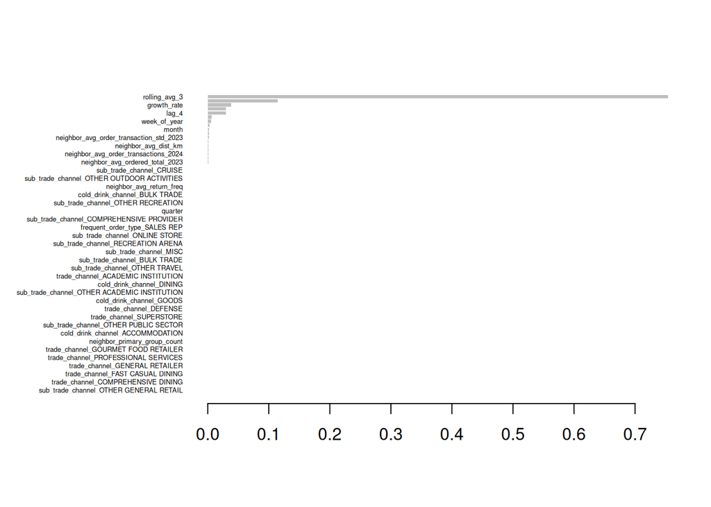

```r
# older customers
importance <- xgb.importance(feature_names = colnames(x_train), model = model)
xgb.plot.importance(importance)
```

```r
setorder(importance, -Importance)
importance
```

```
                                         Feature         Gain        Cover
                                          <char>        <num>        <num>
 1:                                rolling_avg_3 7.545063e-01 3.104910e-01
 2:                                rolling_avg_6 1.148731e-01 1.271948e-01
 3:                                  growth_rate 3.852916e-02 5.307407e-02
 4:                                        lag_1 2.985998e-02 2.740665e-01
 5:                                        lag_4 2.981081e-02 1.308340e-01
 6:                  time_since_onboarding_weeks 6.563868e-03 2.045458e-02
 7:                                 week_of_year 5.538861e-03 6.103666e-03
 8:                                        lag_6 2.806888e-03 5.576922e-02
 9:                                        month 2.186922e-03 3.796821e-04
10:              neighbor_avg_ordered_total_2024 1.708787e-03 2.119763e-05
11:      neighbor_avg_order_transaction_std_2023 1.564109e-03 5.888811e-05
12:         neighbor_avg_order_transactions_2023 1.455365e-03 1.369886e-05
13:                         neighbor_avg_dist_km 1.388656e-03 1.894200e-05
```

[output cut: 137 more lines]

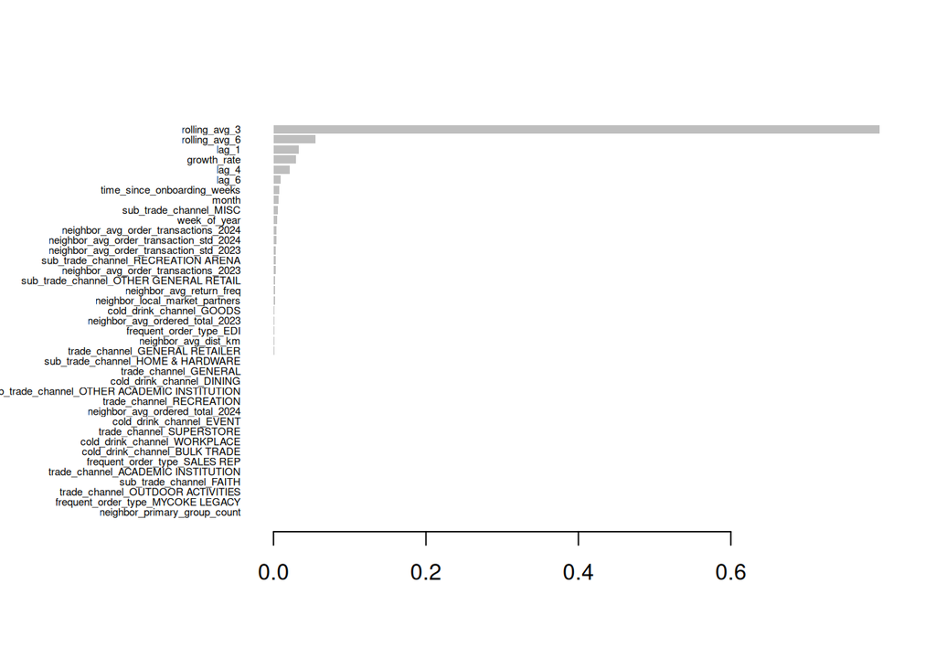

```r
# new customers
importance_new <- xgb.importance(feature_names = colnames(x_train_new), model = model_new)
xgb.plot.importance(importance_new)
```

```r
setorder(importance_new, -Importance)
importance_new
```

```
                                         Feature         Gain        Cover
                                          <char>        <num>        <num>
 1:                                rolling_avg_3 7.954606e-01 3.978364e-01
 2:                                rolling_avg_6 5.466015e-02 1.028271e-01
 3:                                        lag_1 3.295927e-02 2.250057e-01
 4:                                  growth_rate 2.943202e-02 8.575917e-02
 5:                                        lag_4 2.151184e-02 5.950002e-02
 6:                                        lag_6 9.414794e-03 5.631450e-02
 7:                  time_since_onboarding_weeks 7.996602e-03 2.024968e-02
 8:                                        month 6.391846e-03 4.603507e-05
 9:                       sub_trade_channel_MISC 5.745969e-03 2.481082e-02
10:                                 week_of_year 4.940163e-03 7.262601e-05
11:         neighbor_avg_order_transactions_2024 4.161465e-03 7.286556e-05
12:      neighbor_avg_order_transaction_std_2024 3.532216e-03 1.176230e-04
13:      neighbor_avg_order_transaction_std_2023 3.138890e-03 9.147124e-05
```

[output cut: 69 more lines]

### Insights

max_depth = 6 to control complexity min_child_weight = 5 to prevent overly small data splits subsample = 0.8 to improve generalization colsample_bytree = 0.7 to randomly sample features and reduce overfitting

### Future Improvements

While the current forecast models perform okay, several enhancements could further improve forecasting accuracy. Additionally, while this model is focused on forecasting future orders, more needs to be done to be able to identify “high-growth” customers.

Some general future model enhancements could include:

- Exploring additional/separate hyperparameter tuning for each model (new and more established customers)
- Exploring dynamic lag features for individual customer segments like trade channel, cold drink channel, etc. could improve forecast precision, specifically for volatile more customers

Some future steps could include:

- Adjusting the growth rate feature to track growth over different time periods, like 3, 6, and 12 weeks, to capture short-term jumps and steady growth.
- Adding new features such as how often orders are increasing, how quickly orders are happening, and changes in order size can highlight customers on a growth path.
- Grouping customers by trade channel, order type, or how long they’ve been a customer can also make it easier to spot high-growth pattern

## Conclusion

By leveraging data-driven modeling techniques, we enhance Swire Coca-Cola’s ability to segment customers and predict ordering behavior. These insights enable more efficient resource allocation, reduce costs, and identify growth opportunities. Moving forward, continuous refinement of models and integration of additional data sources will further optimize decision-making and operational strategies.

## Division of Work

This group modeling assignment was made possible through the collaborative efforts of all team members. Together, we gathered and cleaned transactional, customer, and delivery cost data, ensuring accuracy and consistency. We engineered key features to strengthen clustering and predictive modeling, utilizing various techniques to enhance customer segmentation and forecasting. Through our combined efforts, we refined data-driven strategies to optimize Swire Coca-Cola’s distribution model.

Thank you,

Adam, Georgia, Tyler, Zac